# Taxes

Kevin Crotty  
BUSI 448: Investments

## Where are we?

**Last time**:

- Economics of asset mgt
- Alphas
- Attribution Analysis
- Market Timing

**Today**:

- Tax-advantaged Accounts
- Tax-advantaged Securities

# Taxation Primer

## Tax Brackets

**Progressive taxation**: income is taxed at higher rates as more is earned

- The first dollar earned is taxed less than the last dollar earned.
- **Marginal** tax rate refers to the tax rate owed on next dollar you earn.

## Tax Brackets

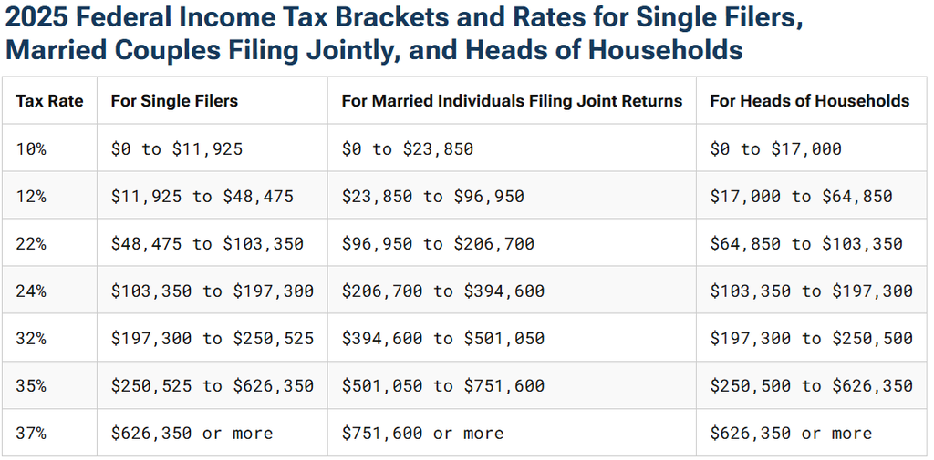

## Deductions shield income from taxation

- Some retirement savings are tax-deductible
- Standard deductions vs. itemized deductions
  - Single filer: $15,750
  - Married filing jointly: $31,500
- Itemized deductions
  - Mortgage interest
  - State and local taxes (SALT)
  - Charitable contributions

## General schedule

Gross Income

-Tax-Deductible Savings Contributions

-Other Deductible Items

=Adjusted Gross Income (AGI)

-Standard or Itemized Deduction

=Taxable Income

- Tax is calculated based on taxable income and filing status

## Example

- Consider a single investor earning $80,000 per year.
- Assume they take the standard deduction of $15,750.
- Under the 2025 tax rates & brackets, what is the investor’s tax bill if they do not have any other deductions?
- What is the investor’s tax bill if they have contributed $7,000 to a traditional IRA?

## Taxes and investments

- Investments are made in the hopes of generating income or price appreciation.
- The source of the return can impact the taxes owed.
- Interest income is taxed at ordinary income rates.
- Capital gains are taxed at different capital gains rates.
  - Is holding period short- or long-term?
  - Limits on deductibility of capital losses
  - Gain is calculated relative to your **cost basis**

## 2025 LT capital gains rates

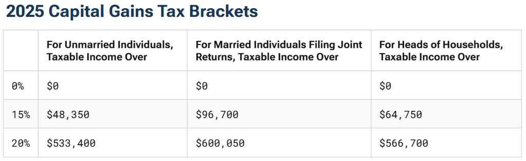

# Tax-advantaged Accounts

## Our benchmark

- We will explore how account taxation can affect the future value of investments.
- Our benchmark will be an investment with no tax advantages in which any gains are taxed immediately at ordinary income rates.

## Some terminology and assumptions

We will assume 2 sets of tax rates:

1. Ordinary income rates $\tau_{oi}$
2. Capital gains rates $\tau_{cg}$.
- We will assume constant tax rates from time $t=0$ to time $t=T-1$ before changing to new rates at time $T$
  - individual’s tax brackets may change in somewhat predictable ways
- 4 possible tax rates: $\tau_{oi,0}$, $\tau_{oi,T}$, $\tau_{cg,0}$, $\tau_{cg,T}$.

## Tax Treatment #1

- No tax benefits
- Gains are taxed immediately at ordinary income rates

$$FV_1 = \Pi_{t=1}^T \left(1+r_t(1-\tau_{oi,t})\right) \,.$$

- Examples: bank accounts, money market accounts, and non-tax-advantaged bonds

## Tax treatment #2

- Non-deductible IRA
- Contributions are in after-tax dollars
- Taxation on gains is deferred until withdrawal at which time they are taxed as *ordinary income*

$$\begin{align*}
FV_2 =& \Pi_{t=1}^T (1+r_t) - \tau_{oi,T} \left[\Pi_{t=1}^T (1+r_t) - 1\right] \\
=& (1-\tau_{oi,T})\Pi_{t=1}^T (1+r_t) + \tau_{oi,T}
\end{align*}$$

## Tax treatment #3

- Non-dividend stock
- Investment made with after-tax dollars
- Taxation on gains is deferred until sale at which time they are taxed as *capital gains*

$$\begin{align*}
FV_3 =& \Pi_{t=1}^T (1+r_t) - \tau_{cg,T} \left[\Pi_{t=1}^T (1+r_t) - 1\right] \\
=& (1-\tau_{cg,T})\Pi_{t=1}^T (1+r_t) + \tau_{cg,T}
\end{align*}$$

## Tax treatment #4

- Roth IRA or a 529 college savings plan
- Contributions are made using after-tax dollars and earnings are tax-exempt

A dollar of after-tax investment turns into
$$FV_4 = \Pi_{t=1}^T \left(1+r_t\right) \,.$$

## Tax treatment #5

- Traditional IRA or 401(k)/403(b) retirement plan.
- Contributions are made using pre-tax dollars (that is, contributions are tax deductible)
- Earnings are tax-deferred $\rightarrow$ withdrawals taxed at ordinary income rates
  - withdrawals of both initial investment and gains

## Tax treatment #5 (cont’d)

- Because the contribution is tax deductible, you save $\tau_{oi,0}$ of taxes that would have otherwise been paid.
- The after-tax cost upon contribution is thus $1-\tau_{oi,0}.$
- The investment account grows to a time $T$ value of $\Pi_{t=1}^T \left(1+r_t\right)$ which is all taxed at withdrawal generating an after-tax time $T$ value of $(1-\tau_{oi,T})\Pi_{t=1}^T \left(1+r_t\right)$.

## Tax treatment #5 (cont’d)

After-tax return (after-tax FV/after-tax contribution):
$$FV_5 = \frac{(1-\tau_{oi,T})\Pi_{t=1}^T \left(1+r_t\right)}{1-\tau_{oi,0}}$$

## Traditional vs. Roth IRAs

**If $\tau_{oi,0}=\tau_{oi,T}$, traditional and Roth IRAs are equivalent on an after-tax basis.**

- Roth IRAs are preferred if an investor’s tax rate is expected to be higher at withdrawal.
  - Better to pay taxes at low rate today
- Traditional IRAs are preferred if an investor’s tax rate is expected to be lower at withdrawl.
  - Better to shield taxes at high rate today

## Asset location vs. asset allocation

**Asset allocation**: the choice of how much of each asset to hold

**Asset location**: the choice of where to locate different asset classes if different tax-advantaged accounts are available.

- This is a challenging problem!
- Investors with different expected tax rates may come to different allocation and location decisions.
- Rule of thumb: Hold more heavily taxed assets (corporate and Treasury bonds) in tax-deferred accounts and lightly-taxed assets (stocks) in taxable accounts

# Tax-advantaged Securities

## Mortgages

- For households, mortgage interest is tax-deductible, up to some limits.
  - Deduction reduces taxable income
  - Tax savings is:
    $$\tau_{\text{marginal}} \cdot \text{Deductible Mortgage Interest}$$

## 2025 tax year

- Mortgage interest expense on principal up to $750,000 is tax deductible.
- Taxpayer must itemize deductions rather than take the standard deduction
  - Single filer: $15,750
  - Married filing jointly: $31,500

## Example

- The annual interest expense for a $500,000 mortgage with a 5% interest rate is $24,832.47 in the first year.
- For an investor with a 24% marginal tax rate and a $15,750 standard deduction, what is the incremental value of itemizing deductions?

## Municipal Bonds

- Municipal bonds: issued by states and municipalities
- In an investor’s home state, muni coupons and original issue discount (OID) are exempt from state income tax
  - US treasury bonds are also exempt from state and local taxes
- Many munis qualify as exempt from federal income tax
- Munis are primarily held by individuals (in the issuing state) who accept a lower yield than they would for a comparable taxable bond.

## Muni yields and after-tax income

After-tax income on a $10,000 investment

| Marginal Federal Tax Rate | 3.2% Muni Bond | 5% US Treasury |
| --- | --- | --- |
| 0% | $320 | $500 |
| 24% | $320 | $380 |
| 32% | $320 | $340 |
| 35% | $320 | $325 |
| 37% | $320 | $315 |

# Other tax topics

## ETFs versus mutual funds

- ETFs are generally more tax-efficient than mutual funds.
- Flows in and out of mutual funds may generate sales of underlying assets in the mutual fund.
  - Resulting capital gains are passed on to the fund investor
- ETF investors thus are able to substantially defer capital gains taxation

## Roth IRAs and skewed returns

- Withdrawals from Roth IRAs do not incur any tax.
- This tax treatment can be extraordinarily valuable for highly skewed assets.
- A famous example is Peter Thiel (PayPal founder and venture capitalist)
- Thiel’s Roth IRA is over $5 billion!
- Congress will likely cap the maximum balance that will be tax-free
- Paying attention to taxes pays…sometimes big!

# For next time: Review

[figure not shown]